# In-class Activity: Visualization Basics

## Mammal sleep data

We will be working with the `msleep` data set that is provided with ggplot2. The data set contains information about the sleep habits of 83 mammals. Enter `?msleep` on the R command line to learn more about the dataset.

Let’s say we want to show a few rows of the `msleep` data in the report. You can use the base R function `head()` to see the first few rows of data:

```
## # A tibble: 6 x 11
##   name  genus vore  order conservation sleep_total sleep_rem sleep_cycle awake
##   <chr> <chr> <chr> <chr> <chr>              <dbl>     <dbl>       <dbl> <dbl>
## 1 Chee… Acin… carni Carn… lc                  12.1      NA        NA      11.9
## 2 Owl … Aotus omni  Prim… <NA>                17         1.8      NA       7
## 3 Moun… Aplo… herbi Rode… nt                  14.4       2.4      NA       9.6
## 4 Grea… Blar… omni  Sori… lc                  14.9       2.3       0.133   9.1
## 5 Cow   Bos   herbi Arti… domesticated         4         0.7       0.667  20
## 6 Thre… Brad… herbi Pilo… <NA>                14.4       2.2       0.767   9.6
## # … with 2 more variables: brainwt <dbl>, bodywt <dbl>
```

But that’s sort of ugly, and the output is cut off. Now try wrap this same command in the `knitr` function `kable()` to create a nice-looking table.

| name | genus | vore | order | conservation | sleep_total | sleep_rem | sleep_cycle | awake | brainwt | bodywt |
| --- | --- | --- | --- | --- | --- | --- | --- | --- | --- | --- |
| Cheetah | Acinonyx | carni | Carnivora | lc | 12.1 | NA | NA | 11.9 | NA | 50.000 |
| Owl monkey | Aotus | omni | Primates | NA | 17.0 | 1.8 | NA | 7.0 | 0.01550 | 0.480 |
| Mountain beaver | Aplodontia | herbi | Rodentia | nt | 14.4 | 2.4 | NA | 9.6 | NA | 1.350 |
| Greater short-tailed shrew | Blarina | omni | Soricomorpha | lc | 14.9 | 2.3 | 0.1333333 | 9.1 | 0.00029 | 0.019 |
| Cow | Bos | herbi | Artiodactyla | domesticated | 4.0 | 0.7 | 0.6666667 | 20.0 | 0.42300 | 600.000 |
| Three-toed sloth | Bradypus | herbi | Pilosa | NA | 14.4 | 2.2 | 0.7666667 | 9.6 | NA | 3.850 |

#### **Problem 1:**

Create a scatter plot of total time asleep (y) vs. brain weight (x), colored by “vore” (carnivore, herbivore, etc.).

- What perceptual problems does this figure have, and what change could you make to show the data more effectively?
- What specifically causes these problems?

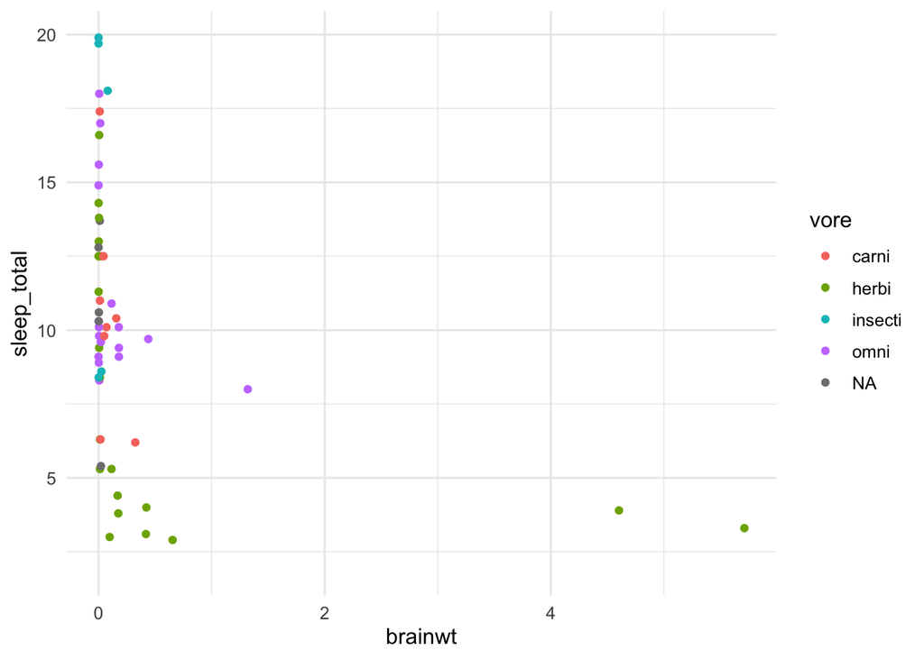

#### **Problem 2:**

Create a new scatter plot of total time asleep vs. brain weight colored by vore, but this time when you plot the variables, consider whether a linear scale or a logarithmic scale seems more appropriate. **HINT:** Use the functions `scale_x_log10()` and/or `scale_y_log10()` to change the scales of the x-axis and y-axis, respectively.

- Explain your reasoning for which scale transformations are most appropriate for displaying the data.
- In your opinion, what is the main story told by this visualization?

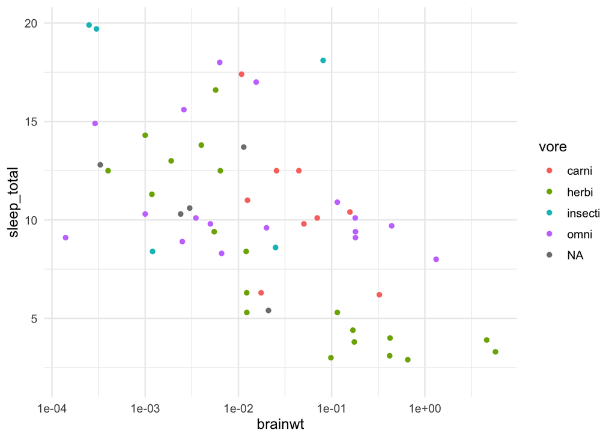

#### **Problem 3:**

Create the same plot of total time asleep vs. brain weight, colored by “vore,” but this time label the points using the name of the animal.

**HINT:** Use the function `geom_text()` and be sure to supply it with the proper aesthetic (type `?geom_text()` and see the bolded entries under “Aesthetics” in the help file).

- What perceptual problems does this figure have?

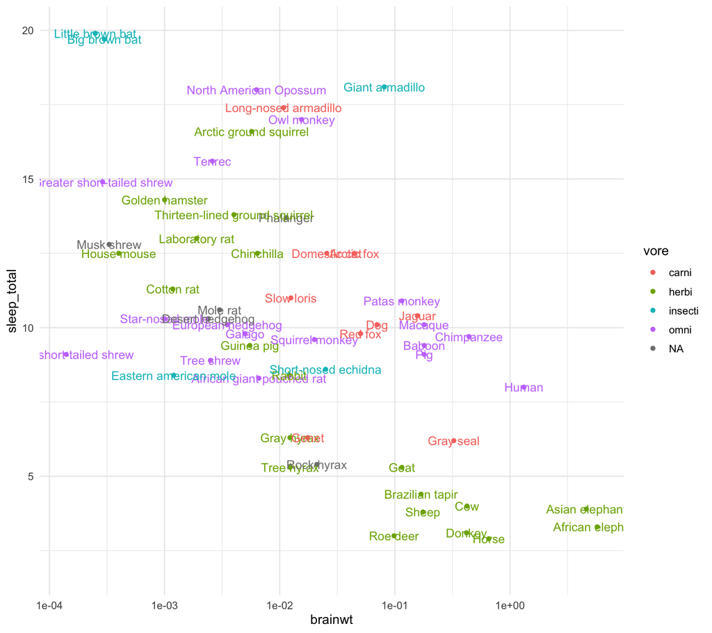

#### **Problem 4:**

This was all an elaborate setup to introduce you to the `ggrepel` package, which is one example of the many helpful “extensions” that people have created for `ggplot2`. Install this package in the usual way:

Now, modify the same plot of total time asleep vs. brain weight, colored by “vore” and labeled with the name of the animal. But this time, instead of using `geom_text()`, use the `geom_text_repel()` function provided by this packages.

- What has changed in your figure?
- How does the change improve the interpretability of the data?

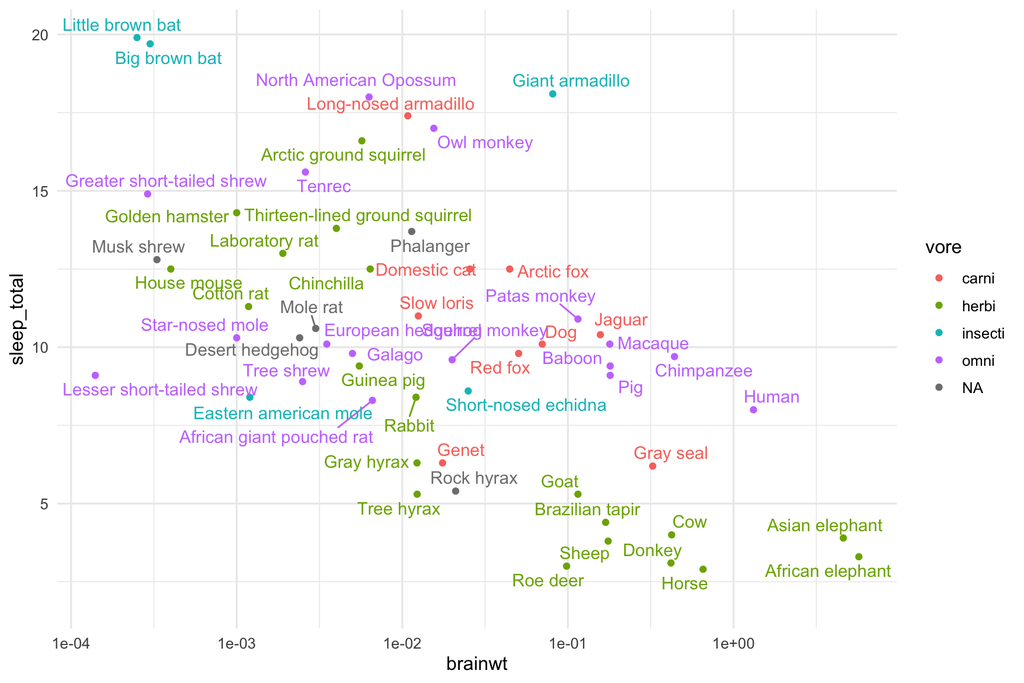

#### **Problem 5:**

Add a linear regression line to the plot using the function `geom_smooth()`.

**Hint:** A regression line can be added with the function `geom_smooth(method = "lm")` (“lm” stands for “linear model”).

Play around with the relative position of the smoothed line by putting it above or below the other geoms. Try also to use `se = FALSE` to see the line without a confidence region around the smooth.

- How has the addition of the line changed the figure’s interpretability?
- Can you find any interesting “stories” in the data that have been revealed?

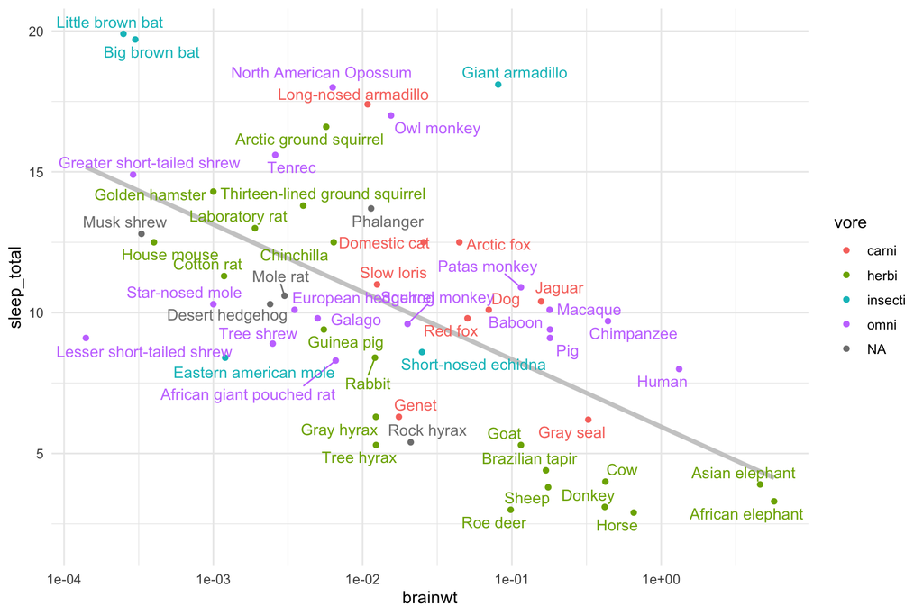